# Report-2025-0331

Minhong Zhu

2025-03-31

## Alignment

The script below includes several key functions:

1. Downloads raw FASTQ data.
2. Performs quality control using FastQC.
3. Aligns reads to the reference genome using STAR.
4. Assesses alignment quality with Qualimap.

```bash
#! /bin/bash -l

sample_id=(SRR6244046 SRR6244047 SRR6244048 SRR6244049 SRR6244050 SRR6244051 \
           SRR6244052 SRR6244053 SRR6244054 SRR6244055 SRR6244056 SRR6244057 SRR6244058)

sample_name=(bm_cd69neg_ind1_1 bm_cd69neg_ind1_2 bm_cd69neg_ind2 bm_cd69neg_ind3 ln_cd69neg_ind1 \
             ln_cd69neg_ind3 ln_cd69neg_ind2 bm_cd69pos_ind1 bm_cd69pos_ind2 bm_cd69pos_ind3 \
             ln_cd69pos_ind1 ln_cd69pos_ind3 ln_cd69pos_ind2)

skip_samples=("bm_cd69neg_ind1_1" "bm_cd69neg_ind1_2")

for i in "${!sample_id[@]}"; do
    srr="${sample_id[$i]}"
    sample="${sample_name[$i]}"
    fq1="./raw_fastq/${srr}_1.fastq.gz"
    fq2="./raw_fastq/${srr}_2.fastq.gz"
    renamed_fq1="./raw_fastq/${sample}_1.fastq.gz"
    renamed_fq2="./raw_fastq/${sample}_2.fastq.gz"

    echo "Processing $srr -> $sample"

    # === Check if FASTQ files already downloaded ===
    conda activate angsd
    if [[ -f "$fq1" && -f "$fq2" ]]; then
        echo "FASTQ files for $srr already downloaded."

        # Rename if not already renamed
        if [[ ! -f "$renamed_fq1" ]]; then
            mv "$fq1" "$renamed_fq1"
            echo "Renamed $fq1 to $renamed_fq1"
        fi
        if [[ ! -f "$renamed_fq2" ]]; then
            mv "$fq2" "$renamed_fq2"
            echo "Renamed $fq2 to $renamed_fq2"
        fi
    elif [[ -f "$renamed_fq1" && -f "$renamed_fq2" ]]; then
        echo "Renamed FASTQ files for $sample already exist. Skipping download."
    else
        echo "Downloading FASTQ files for $srr"
        conda activate angsd
        # fastq-dump --split-files --gzip -O ./raw_fastq "$srr"
        fasterq-dump $srr --split-files -O ./raw_fastq --threads 16

        # Compress
        pigz -p 16 ./raw_fastq/${srr}_1.fastq
        pigz -p 16 ./raw_fastq/${srr}_2.fastq

        # Rename after download
        mv "$fq1" "$renamed_fq1"
        mv "$fq2" "$renamed_fq2"

        # === FastQC ===
        fastqc "$renamed_fq1" "$renamed_fq2" -o ./raw_fastq/fastqc_raw_report

    fi

    # === Skip samples from bw_cd69neg_ind1 ===
    if [[ " ${skip_samples[@]} " =~ " ${sample} " ]]; then
        echo "Skipping alignment for $sample (marked for later processing)"
        continue
    fi

    # === STAR Alignment ===
    mkdir -p "./alignment/${sample}"
    STAR --runMode alignReads \
        --runThreadN 16 \
        --genomeDir /athena/angsd/scratch/miz4010/project/refGenomes/hg38_STARindex \
        --readFilesIn "$renamed_fq1" "$renamed_fq2" \
        --readFilesCommand zcat \
        --alignIntronMax 100000 \
        --alignSJDBoverhangMin 3 \
        --outFileNamePrefix "./alignment/${sample}/${sample}.STAR." \
        --outSAMtype BAM SortedByCoordinate \
        --outSAMunmapped Within \
        --outSAMattributes All

    samtools index -@ 16 "./alignment/${sample}/${sample}.STAR.Aligned.sortedByCoord.out.bam"

    # === Qualimap ===
    conda activate qualimap
    qualimap bamqc -bam "./alignment/${sample}/${sample}.STAR.Aligned.sortedByCoord.out.bam" \
        -outformat PDF -outfile "${sample}.STAR.report.pdf"

    echo "Finished processing $sample"
done
```

The bone marrow CD69⁻ sample from donor 1 was split into two sub-samples due to multiplexing. After quality control, no significant technical bias was detected between them. Therefore, the two sub-samples were concatenated prior to alignment. The corresponding scripts are provided below.

```bash
#! /bin/bash -l

zcat ./raw_fastq/bm_cd69neg_ind1_1_1.fastq.gz ./raw_fastq/bm_cd69neg_ind1_2_1.fastq.gz | gzip > ./raw_fastq/bm_cd69neg_ind1_1.fastq.gz
zcat ./raw_fastq/bm_cd69neg_ind1_1_2.fastq.gz ./raw_fastq/bm_cd69neg_ind1_2_2.fastq.gz | gzip > ./raw_fastq/bm_cd69neg_ind1_2.fastq.gz

read1="./raw_fastq/bm_cd69neg_ind1_1.fastq.gz"
read2="./raw_fastq/bm_cd69neg_ind1_2.fastq.gz"
sample="bm_cd69neg_ind1"

conda activate angsd

STAR --runMode alignReads \
    --runThreadN 16 \
    --genomeDir /athena/angsd/scratch/miz4010/project/refGenomes/hg38_STARindex \
    --readFilesIn ${read1} ${read2} \
    --readFilesCommand zcat \
    --alignIntronMax 100000 \
    --alignSJDBoverhangMin 3 \
    --outFileNamePrefix "./alignment/${sample}/${sample}.STAR." \
    --outSAMtype BAM SortedByCoordinate \
    --outSAMunmapped Within \
    --outSAMattributes All

samtools index -@ 16 "./alignment/${sample}/${sample}.STAR.Aligned.sortedByCoord.out.bam"

conda activate qualimap
qualimap bamqc -bam "./alignment/${sample}/${sample}.STAR.Aligned.sortedByCoord.out.bam" \
    -outformat PDF -outfile "${sample}.STAR.report.pdf"

echo "Finished processing $sample"
```

## Quality control and read count generation

The following script runs QoRTs to perform additional alignment quality checks.

```bash
#! /bin/bash -l

conda activate qorts
qorts_jar="/athena/angsd/scratch/diz4009/qorts/hartleys-QoRTs-099881f/QoRTs.jar"

sample_name=(bm_cd69neg_ind1 bm_cd69neg_ind2 bm_cd69neg_ind3 ln_cd69neg_ind1 \
             ln_cd69neg_ind3 ln_cd69neg_ind2 bm_cd69pos_ind1 bm_cd69pos_ind2 \
             bm_cd69pos_ind3 ln_cd69pos_ind1 ln_cd69pos_ind3 ln_cd69pos_ind2)

for i in "${!sample_name[@]}"; do
    sample="${sample_name[$i]}"

    java -Xmx60G -jar "$qorts_jar" QC \
        --generatePdfReport \
        --stranded \
        --numThreads 24 \
        ./alignment/${sample}/*.bam \
        ./refGenomes/gencode.v47.basic.annotation.gtf \
        ./qorts/${sample}/
done
```

The following scripts use `featureCounts` to generate a read count table. As demonstrated in the later section, a substantial portion of reads is assigned to intronic regions — an indicator of potential data quality issues.

```bash
#! /bin/bash -l

conda activate angsd

mkdir -p ./featureCounts
annot_file="./refGenomes/gencode.v47.basic.annotation.gtf"

featureCounts -T 24 \
    -a ${annot_file} \
    -o ./featureCounts/fc_output.txt \
    -s 2 \
    -t gene \
    -g gene_id \
    -M -O -p --countReadPairs \
    ./alignment/*_cd69*/*.bam
```

The generated read count table can be imported into R using the following code.

```r
sample_names <- c(
  "bm_cd69neg_ind1", "bm_cd69neg_ind2", "bm_cd69neg_ind3",
  "bm_cd69pos_ind1", "bm_cd69pos_ind2", "bm_cd69pos_ind3",
  "ln_cd69neg_ind1", "ln_cd69neg_ind2", "ln_cd69neg_ind3",
  "ln_cd69pos_ind1", "ln_cd69pos_ind2", "ln_cd69pos_ind3"
)

read.counts <- read.table("./featureCounts/fc_output.txt", header = TRUE, comment.char = "#", sep = "\t")
colnames(read.counts)[7:18] <- sample_names
```

## Result analysis

### Fastqc results

In general, the sequencing quality appears to be consistent and acceptable across the samples. The sequence count plots show no clear bias across tissue types (bone marrow vs. lymph node), T cell activation status (CD69+ vs. CD69−), or between different donors.

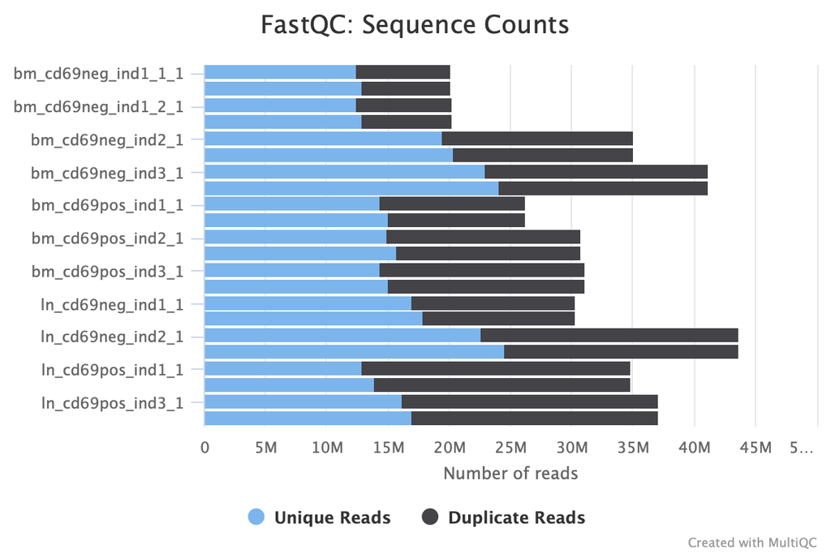

Quality warnings are primarily driven by the GC content distribution and the presence of overrepresented sequences. An abnormal peak at the high-GC region is consistently observed across samples, likely due to the prevalence of GC-rich overrepresented sequences. BLAST analysis of the top five overrepresented sequences reveals that they all correspond to 28S rRNA, indicating potential rRNA contamination during library preparation.

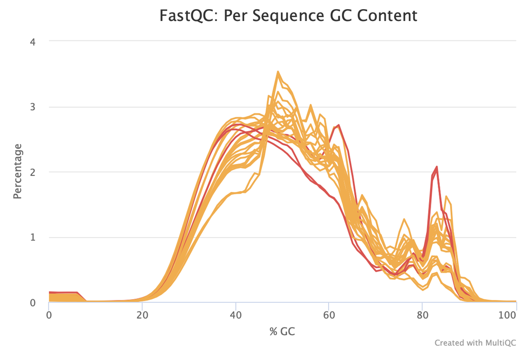

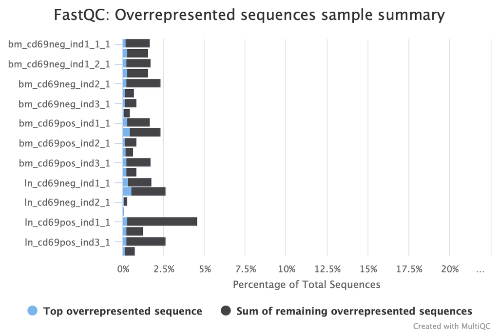

### Qualimap results

Reviewing the alignment statistics provided by STAR reveals that while some samples have a reasonable number of uniquely mapped reads, others—such as the lymph node CD69+ samples from donor 1—show a high proportion of multi-mapping reads. This variation suggests inconsistencies in alignment quality across samples.

[figure not shown]

### Qort results

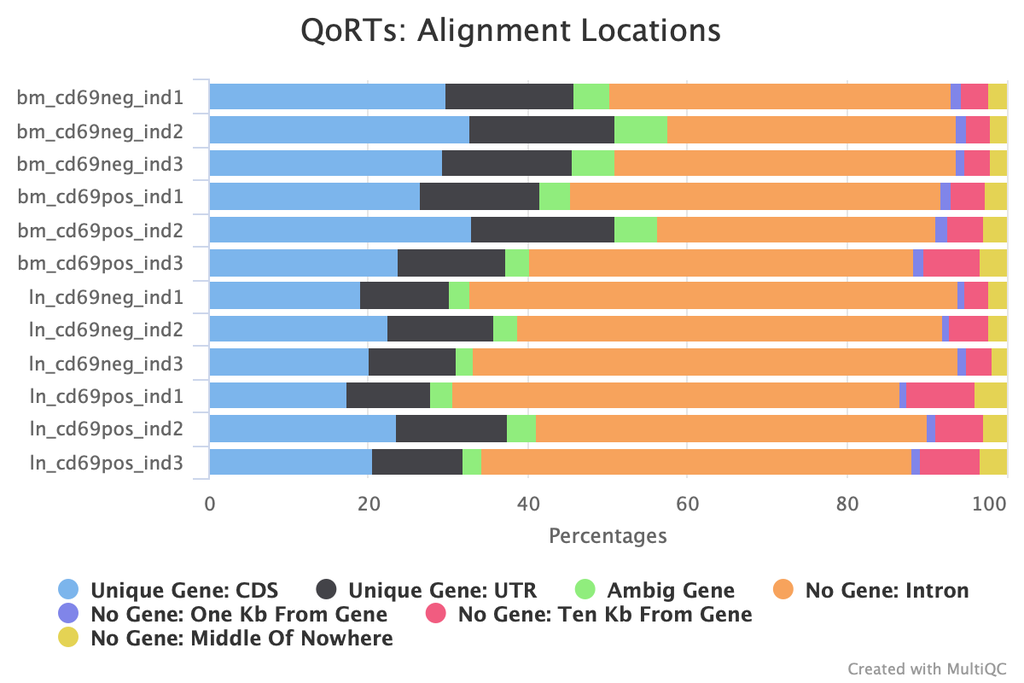

## Concerns

Following alignment and quality control, there are significant concerns about the suitability of the data for downstream analysis, as some samples contain only 20–30% effective exonic reads. If the library preparation protocol was indeed rRNA depletion, I would appreciate guidance on how to appropriately handle potential pre-mRNA reads mapped to intronic regions, in order to minimize bias in subsequent analyses.